# Ecoroof Data Analysis Report

By: Alex Vijay Bans

March 5th, 2023

## Introduction

There were 3 goals to this project. The first goal was to analyze the runoff hydrology and chemistry of a seven-year-old ecoroof on top of a commercial building compared to a segment of conventional roof on the same commercial building. The second goal of this project was to create a reproducible reference for Researchers, Stakeholders, and other interested parties, via a Markdown report and exported figures, tables, and data files. The third goal of this project was to directly be able to pipe the results of this analysis to create interactive dashboards using PowerBI for stakeholders to explore the data further.

## Methods

For the full details of the project, including background research, sampling methods, etc. please refer to the original report located at [title] (https://pdxscholar.library.pdx.edu/open_access_etds/5577/).  
Please note the methods for data analysis and statistical testing, as well as assumptions used may be different from the ones performed in the original report. While the values may be different, the general conclusions reached are similar. Interpretation of the results is not in the scope of this particular project.

#### Software and Libraries

This project was analyzed exclusively with the R language and uses the following libraries: data.table, tidyverse, janitor, lubridate, patchwork, here, kableExtra, and bansr (my personal library of functions I’ve written). Dependencies were managed with Renv.

#### Data Processing

All data first had to be uploaded and tidied in a form to be able to be processed. All data was filtered by the start (09/01/2018) and end (06/01/2019) dates of the project. Additionally, the month of October was removed due to flow sensor malfunctioning. Final results were given with 3 significant figures due to the resolution of the flow meter and rain gauges both being 0.01 inches.

#### Precipitation

First, rain data was imported, and processed before being parsed into discrete storm events (storms). In this project a storm event was defined as having at least 5.02 mm of rain, with an interevent period of at least 24 hours from the previously measurable, greater than 5.02 mm rainfall storm event. Parsing the flow from the roofs was difficult as there was a lag between rainfall and discharge. Thus, all data were separated from the start of the first event, to the start of the next event, instead of the start of the first event to the end of the first event.

#### Roof Discharges

Discharges (Q) from the conventional roof and the eco roof were imported and processed before being combined together. Discharges were then separated into their associated rain events. After discharges that were less than 0.04 L/s were removed due to instrument error, it would detect standing water as flow at those levels. Roof runoff volume (V) was calculated by integrating Q with respect to time (dt) using the trapezoidal rule (0.5*dt*(Q1+Q2)).

#### Runoff Retention

The percent rainfall retention for the sampling period was calculated by first aggregating and summing all the volume of runoff for both roof catchment sizes for each storm event, subtracting it by the total discharge from both the roofs, dividing it by runoff volume and multiplying it by 100.

#### Runoff Sampling

Stormwater metal and nutrient pollutant runoff samples were imported, processed, and joined together. The accuracy and precision of the calibration curves, and standards of each analysis run were not QA/QC’ed for this analysis. Runoff samples results were however compared to the average field and lab blank results and determined that in general there were no sources of contamination from the collection and processing of the runoff samples. It is important to note that, if there were more formal reporting then a stricter post-lab analysis QA/QC process will need to be undertaken.

The runoff samples collected were flow-weight based, meaning they were collected after certain volumes of discharge occurred. This is different from time based samples which are collected in intervals of duration. Flow weighted samples take into account the quantity of discharge. You can thus assume the concentrations sampled at each discrete volume of discharge is representative of the average concentration of that discharged volume of water. For every flow-weighted sample in a storm event, the mean was taken to determine the flow weighted event mean concentration (EMC).

#### Unit Area Loading

Discharge volume was aggregated for each storm event before being joined with the EMC value for each storm event, if available. Taking the EMC * discharge volume / roof catchment size gives us the mass flux (Pa) for each storm event. Calculating unit area load accounts for both the discharge volume as well as the catchment size, effectively normalizing the pollutant data to each other.

#### Statistical Analysis

As this was a longitudinal study where water quality was observed between roof catchments via repeated measures, the observations were considered non-independent. However, there were only two roof catchments observed and thus because the sample size was very low, we we’re limited in how we can interpret the data. We couldn’t use standard statistical inferential testing. Instead of inferential testing and their results, the summary statistics, and the scaled difference between the mean unit area loads for the ecoroof and conventional roof were graphed.

## Results

Below is the visualization of precipitation, roof discharges, and runoff sample collection times for the sample period for the project.

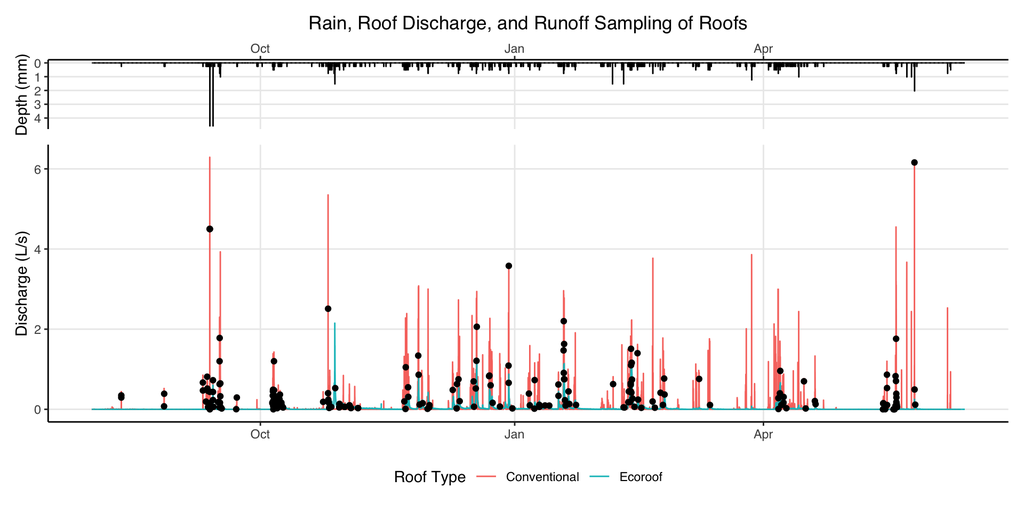

There were a total of 204 metal runoff samples with 141 samples captured during storm events. There were about 105 run off samples captures, with 95 of them being during a storm event.

Below is the total precipitation, roof discharge, and retention for the sampling period.

Precipitation, Discharge, and Roof Retention Rates

| Roof | Rainfall Volume (L) | Discharge Volume (L) | Retention % |
| --- | --- | --- | --- |
| Conventional | 827000 | 720000 | 12.9 |
| Ecoroof | 663000 | 498000 | 24.9 |

There were 33 storm events during the project sampling period. See the table and figure below for the detailed breakdown of each storm event and the discharge for both roof during the parsed storm events.

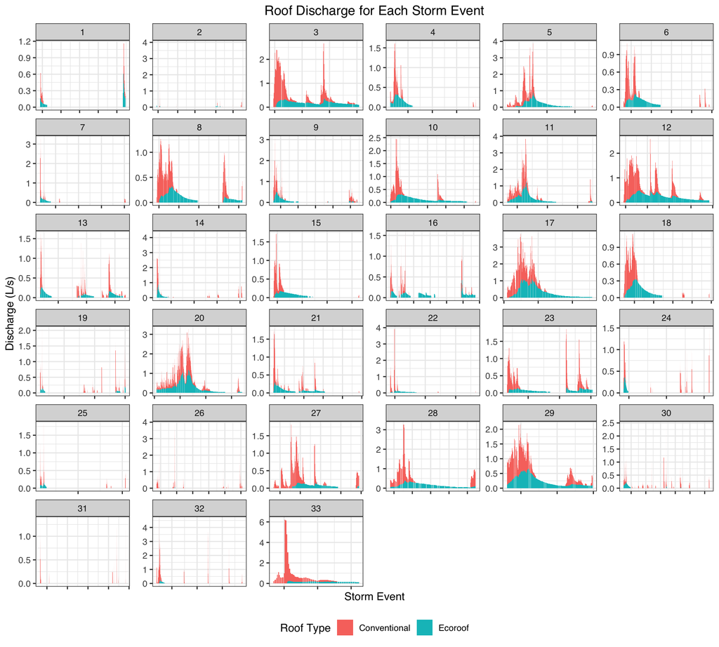

Summary of Parsed Storm Events

| Storm | Start | Duration (hr) | Depth (mm) |
| --- | --- | --- | --- |
| 1 | 2018-09-12 17:15:00 | 4.25 | 12.40 |
| 2 | 2018-09-13 20:50:00 | 2.25 | 11.90 |
| 3 | 2018-11-22 11:45:00 | 5.50 | 9.40 |
| 4 | 2018-11-23 06:30:00 | 8.92 | 7.11 |
| 5 | 2018-11-26 18:50:00 | 13.50 | 16.00 |
| 6 | 2018-11-28 07:35:00 | 8.67 | 6.60 |
| 7 | 2018-11-30 15:05:00 | 3.83 | 6.60 |
| 8 | 2018-12-09 10:40:00 | 11.08 | 13.00 |
| 9 | 2018-12-11 14:10:00 | 9.25 | 10.70 |
| 10 | 2018-12-16 11:50:00 | 5.42 | 6.10 |
| 11 | 2018-12-17 15:50:00 | 18.50 | 26.20 |
| 12 | 2018-12-22 17:25:00 | 6.92 | 11.70 |
| 13 | 2018-12-23 17:05:00 | 4.92 | 5.59 |
| 14 | 2018-12-29 17:55:00 | 6.83 | 11.20 |
| 15 | 2019-01-06 10:05:00 | 5.67 | 5.33 |
| 16 | 2019-01-08 03:25:00 | 7.42 | 6.35 |
| 17 | 2019-01-18 13:05:00 | 15.00 | 25.10 |
| 18 | 2019-01-20 05:20:00 | 11.75 | 10.90 |
| 19 | 2019-01-22 10:45:00 | 6.00 | 5.33 |
| 20 | 2019-02-11 02:10:00 | 38.42 | 44.70 |
| 21 | 2019-02-14 10:10:00 | 7.17 | 6.86 |
| 22 | 2019-02-19 20:10:00 | 7.75 | 6.60 |
| 23 | 2019-02-22 15:55:00 | 6.17 | 5.59 |
| 24 | 2019-02-24 00:40:00 | 9.75 | 9.14 |
| 25 | 2019-03-11 23:10:00 | 8.25 | 7.62 |
| 26 | 2019-03-25 12:10:00 | 7.08 | 5.59 |
| 27 | 2019-04-05 04:05:00 | 11.58 | 8.38 |
| 28 | 2019-04-06 05:25:00 | 5.92 | 7.62 |
| 29 | 2019-04-06 19:25:00 | 11.67 | 18.00 |
| 30 | 2019-04-07 23:45:00 | 12.08 | 6.60 |
| 31 | 2019-04-19 14:55:00 | 10.25 | 5.84 |
| 32 | 2019-05-18 19:05:00 | 12.00 | 21.30 |
| 33 | 2019-05-25 14:05:00 | 7.67 | 11.70 |

Below is the event mean concentrations of pollutants for each storm event.

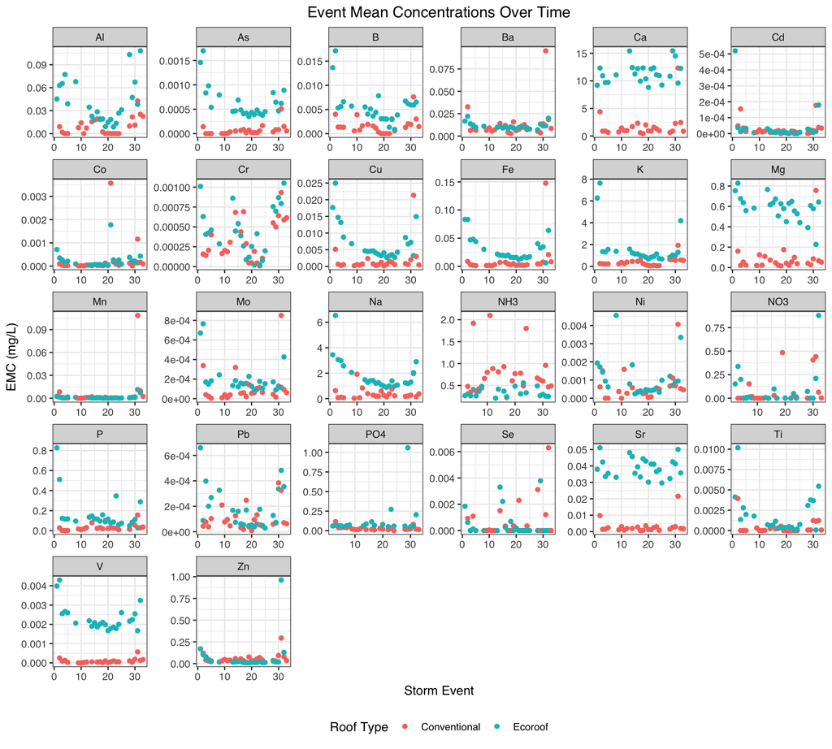

Summary Table for Pollutant Unit Area Loads (mg/m^2)

| Pollutant | Roof | n | Min | IQR | Max | Median | Mean | SD |
| --- | --- | --- | --- | --- | --- | --- | --- | --- |
| Al | Conventional | 24 | 0.00e+00 | 2.17e-01 | 6.05e-01 | 9.005e-02 | 0.1528750 | 0.1883237 |
| Al | Ecoroof | 23 | 3.60e-02 | 4.81e-01 | 9.63e-01 | 5.030e-01 | 0.4613043 | 0.3040142 |
| As | Conventional | 24 | 0.00e+00 | 1.49e-03 | 6.03e-03 | 5.575e-04 | 0.0011538 | 0.0014622 |
| As | Ecoroof | 23 | 1.88e-03 | 6.15e-03 | 2.56e-02 | 5.540e-03 | 0.0076191 | 0.0056260 |
| B | Conventional | 24 | 0.00e+00 | 2.12e-02 | 9.01e-02 | 2.055e-02 | 0.0247062 | 0.0234473 |
| B | Ecoroof | 23 | 5.53e-03 | 7.44e-02 | 1.81e-01 | 5.480e-02 | 0.0655357 | 0.0472975 |
| Ba | Conventional | 24 | 2.78e-02 | 1.55e-01 | 1.13e+00 | 1.115e-01 | 0.2049875 | 0.2384653 |
| Ba | Ecoroof | 23 | 2.14e-02 | 9.45e-02 | 4.33e-01 | 1.320e-01 | 0.1411826 | 0.1004588 |
| Ca | Conventional | 24 | 4.39e+00 | 3.13e+01 | 1.46e+02 | 1.650e+01 | 28.4020833 | 31.3016034 |
| Ca | Ecoroof | 23 | 1.18e+01 | 1.03e+02 | 5.22e+02 | 1.250e+02 | 157.2739130 | 125.1243063 |
| Cd | Conventional | 24 | 0.00e+00 | 2.48e-04 | 2.10e-03 | 2.250e-04 | 0.0004105 | 0.0005623 |
| Cd | Ecoroof | 23 | 0.00e+00 | 2.30e-04 | 6.69e-04 | 1.800e-04 | 0.0002260 | 0.0002032 |
| Co | Conventional | 24 | 1.40e-04 | 1.11e-03 | 4.19e-02 | 7.165e-04 | 0.0032554 | 0.0086943 |
| Co | Ecoroof | 23 | 3.53e-04 | 2.00e-03 | 2.52e-02 | 1.720e-03 | 0.0027640 | 0.0050137 |
| Cr | Conventional | 24 | 7.70e-05 | 6.44e-03 | 1.84e-02 | 3.510e-03 | 0.0054802 | 0.0048340 |
| Cr | Ecoroof | 23 | 1.32e-04 | 5.70e-03 | 1.51e-02 | 4.180e-03 | 0.0052931 | 0.0047825 |
| Cu | Conventional | 24 | 2.46e-03 | 1.17e-02 | 2.53e-01 | 9.360e-03 | 0.0271992 | 0.0524745 |
| Cu | Ecoroof | 23 | 1.32e-02 | 9.97e-02 | 2.40e-01 | 6.190e-02 | 0.0836087 | 0.0632985 |
| Fe | Conventional | 24 | 1.16e-02 | 9.09e-02 | 1.75e+00 | 5.295e-02 | 0.1481125 | 0.3551117 |
| Fe | Ecoroof | 23 | 5.94e-02 | 3.74e-01 | 9.34e-01 | 2.720e-01 | 0.3518087 | 0.2406013 |
| K | Conventional | 24 | 4.10e-01 | 4.83e+00 | 2.30e+01 | 4.065e+00 | 6.0179583 | 5.4130925 |
| K | Ecoroof | 23 | 3.66e+00 | 1.41e+01 | 6.11e+01 | 1.390e+01 | 17.4495652 | 13.9748220 |
| Mg | Conventional | 24 | 1.58e-01 | 1.20e+00 | 8.98e+00 | 6.820e-01 | 1.3496250 | 1.8962464 |
| Mg | Ecoroof | 23 | 9.71e-01 | 5.43e+00 | 2.66e+01 | 6.840e+00 | 8.0891739 | 6.3571811 |
| Mn | Conventional | 24 | 0.00e+00 | 2.05e-02 | 1.29e+00 | 1.140e-02 | 0.0796778 | 0.2628585 |
| Mn | Ecoroof | 23 | 0.00e+00 | 1.00e-02 | 2.63e-02 | 4.510e-03 | 0.0087370 | 0.0083690 |
| Mo | Conventional | 24 | 6.85e-05 | 1.95e-03 | 1.01e-02 | 6.960e-04 | 0.0017249 | 0.0023468 |
| Mo | Ecoroof | 23 | 3.96e-04 | 1.74e-03 | 7.52e-03 | 1.590e-03 | 0.0023388 | 0.0018681 |
| NH3 | Conventional | 24 | 2.59e+00 | 1.02e+01 | 5.91e+01 | 1.080e+01 | 13.7608333 | 13.5732470 |
| NH3 | Ecoroof | 19 | 8.62e-01 | 2.97e+00 | 2.86e+01 | 3.510e+00 | 5.4106316 | 6.2004870 |
| NO3 | Conventional | 24 | 0.00e+00 | 3.48e-01 | 1.24e+01 | 1.385e-02 | 1.2239500 | 2.9805235 |
| NO3 | Ecoroof | 19 | 0.00e+00 | 8.38e-01 | 3.48e+00 | 4.530e-02 | 0.7492789 | 1.2477885 |
| Na | Conventional | 24 | 5.19e-01 | 5.82e+00 | 2.33e+01 | 4.170e+00 | 6.1362917 | 5.9066561 |
| Na | Ecoroof | 23 | 4.14e+00 | 2.25e+01 | 5.78e+01 | 1.620e+01 | 21.7073913 | 15.9909484 |
| Ni | Conventional | 24 | 0.00e+00 | 8.53e-03 | 4.82e-02 | 6.210e-03 | 0.0102238 | 0.0125320 |
| Ni | Ecoroof | 23 | 1.21e-03 | 9.25e-03 | 5.42e-02 | 9.430e-03 | 0.0114591 | 0.0113785 |
| P | Conventional | 24 | 1.09e-02 | 7.01e-01 | 2.62e+00 | 3.865e-01 | 0.6153958 | 0.6601480 |
| P | Ecoroof | 23 | 3.13e-01 | 1.12e+00 | 6.81e+00 | 1.270e+00 | 1.7678261 | 1.4864588 |
| PO4 | Conventional | 24 | 4.36e-02 | 2.86e-01 | 1.55e+00 | 3.425e-01 | 0.4477542 | 0.3516761 |
| PO4 | Ecoroof | 19 | 2.20e-01 | 9.28e-01 | 2.09e+01 | 7.040e-01 | 2.2338947 | 4.6766871 |
| Pb | Conventional | 24 | 3.33e-04 | 1.19e-03 | 6.98e-03 | 9.295e-04 | 0.0015068 | 0.0015142 |
| Pb | Ecoroof | 23 | 1.55e-04 | 1.80e-03 | 4.09e-03 | 1.220e-03 | 0.0016897 | 0.0012496 |
| Se | Conventional | 24 | 0.00e+00 | 1.06e-02 | 1.51e-01 | 1.685e-04 | 0.0122078 | 0.0307961 |
| Se | Ecoroof | 23 | 0.00e+00 | 6.02e-03 | 7.46e-02 | 0.000e+00 | 0.0072778 | 0.0176494 |
| Sr | Conventional | 24 | 7.03e-03 | 3.37e-02 | 2.55e-01 | 2.570e-02 | 0.0452388 | 0.0556824 |
| Sr | Ecoroof | 23 | 4.89e-02 | 4.19e-01 | 1.78e+00 | 4.190e-01 | 0.5261261 | 0.4099489 |
| Ti | Conventional | 24 | 0.00e+00 | 5.22e-03 | 6.50e-02 | 4.490e-04 | 0.0066207 | 0.0145511 |
| Ti | Ecoroof | 23 | 3.60e-04 | 2.12e-02 | 8.14e-02 | 1.260e-02 | 0.0193861 | 0.0215605 |
| V | Conventional | 24 | 0.00e+00 | 9.43e-04 | 6.77e-03 | 7.820e-04 | 0.0014043 | 0.0015665 |
| V | Ecoroof | 23 | 5.13e-03 | 2.24e-02 | 9.88e-02 | 2.540e-02 | 0.0294113 | 0.0212555 |
| Zn | Conventional | 24 | 1.52e-01 | 7.95e-01 | 3.49e+00 | 6.475e-01 | 0.9445833 | 0.7912585 |
| Zn | Ecoroof | 23 | 5.17e-02 | 2.60e-01 | 9.71e-01 | 2.190e-01 | 0.3361087 | 0.2702477 |

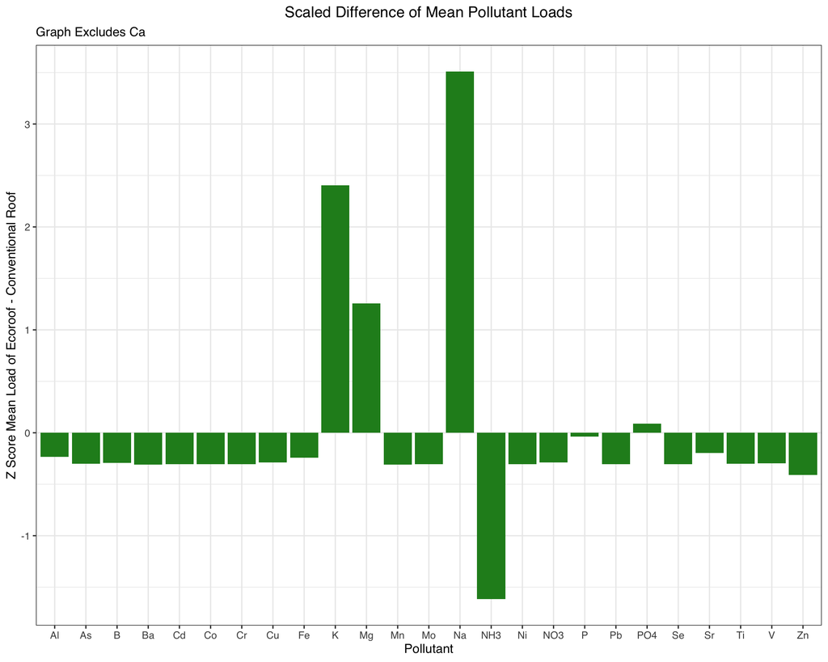

## Going Forward

The next goal of this project is to export the data to create interactive dashboards using PowerBI.